# KNN_Advertising_DA

We are going to predict what the sales in units of thousands will be based on the budget (in 1000 usd) invested in 3 different media: TV, Radio, and Newspaper.

```python
# Import required libraries
import numpy as np
import pandas as pd
import matplotlib.pyplot as plt
from sklearn.neighbors import KNeighborsRegressor
from sklearn.model_selection import train_test_split
from sklearn.metrics import mean_squared_error
from sklearn.metrics import r2_score
from sklearn.model_selection import cross_val_score
```

```python
# Read the data and take a quick look
filename='Advertising.csv'
df = pd.read_csv(filename)
df.head()
```

|  | TV | Radio | Newspaper | Sales |
| --- | --- | --- | --- | --- |
| 0 | 230.1 | 37.8 | 69.2 | 22.1 |
| 1 | 44.5 | 39.3 | 45.1 | 10.4 |
| 2 | 17.2 | 45.9 | 69.3 | 9.3 |
| 3 | 151.5 | 41.3 | 58.5 | 18.5 |
| 4 | 180.8 | 10.8 | 58.4 | 12.9 |

```python
# Let's make our first kind of KNN model ("A" type) where our predictor will be TV budget and 'Sales' will be the response variable
X_A = df[['TV']]; Y_A = df['Sales']
```

```python
# We split the dataset in training and testing sets with 60% of the data being for training with random_state=66
X_A_train, X_A_test, Y_A_train, Y_A_test = train_test_split(X_A,Y_A,train_size=0.6,random_state=66)
```

```python
# we choose the number of nearest neighbors k to range from 1 to 70
k_value_min=1; k_value_max=70
k_list = np.linspace(k_value_min,k_value_max,num=70,dtype=int)
```

```python
# create 2 dictionaries to store the k values and their corresponding MSE and R^2 values
knn_dict_mse_A = {}; knn_dict_r2_A ={}
```

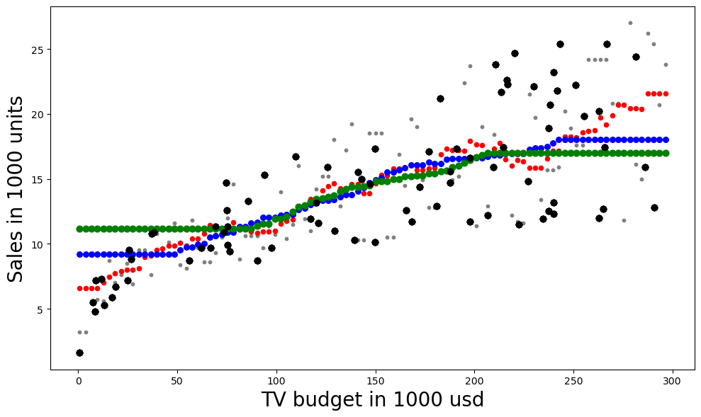

```python
# loop over all k values and predict the sales for eack number of neighbors

# also plot some KNN models for display #####
plt.figure(figsize=(10,6))
colors=['grey','r','b','g']
j=0
#############################################

for k_value in k_list:
    model_A = KNeighborsRegressor(n_neighbors=int(k_value))
    model_A.fit(X_A_train,Y_A_train)
    Y_A_hat = model_A.predict(X_A_test)
    MSE_A = mean_squared_error(Y_A_test,Y_A_hat)
    knn_dict_mse_A[k_value]=MSE_A
    scores_A = cross_val_score(model_A,X_A,Y_A,cv=3)
    R2_A = np.mean(scores_A)
    knn_dict_r2_A[k_value]=R2_A
    ##########################################
    if k_value in [1,10,40,70]:
            xvals = np.linspace(X_A.min(),X_A.max(),100)
            ypreds = model_A.predict(xvals)
            plt.scatter(xvals,ypreds,c=colors[j],s=(10*j)+10)
            j+=1
            plt.scatter(X_A_test,Y_A_test,c='k')
            plt.xlabel('TV budget in 1000 usd',fontsize=20)
            plt.ylabel('Sales in 1000 units',fontsize=20)
            plt.tight_layout()
```

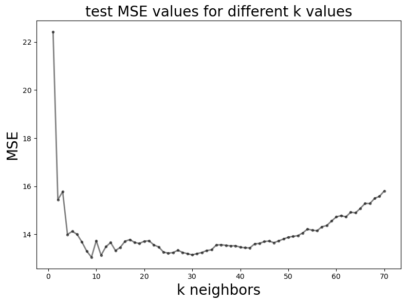

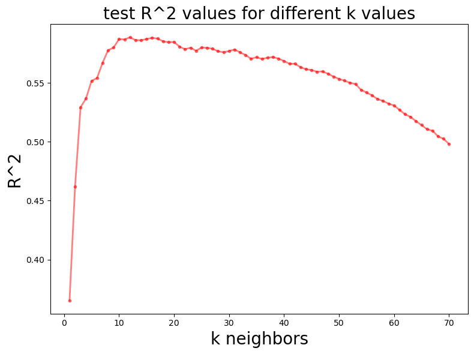

```python
# plot a graph which depicts the relation between the k values and MSE, R^2
plt.figure(figsize=(8,6))
plt.plot(knn_dict_mse_A.keys(),knn_dict_mse_A.values(),'k.-',alpha=0.5,linewidth=2)
plt.xlabel('k neighbors',fontsize=20)
plt.ylabel('MSE',fontsize=20)
plt.title('test MSE values for different k values',fontsize=20)
plt.tight_layout()

plt.figure(figsize=(8,6))
plt.plot(knn_dict_r2_A.keys(),knn_dict_r2_A.values(),'r.-',alpha=0.5,linewidth=2)
plt.xlabel('k neighbors',fontsize=20)
plt.ylabel('R^2',fontsize=20)
plt.title('test R^2 values for different k values',fontsize=20)
plt.tight_layout()
```

```python
# find the lowest MSE and highest R^2 among all type A KNN models in order to decide which predicts the Sales better
min_MSE_A = min(knn_dict_mse_A.values())
for k,mse in knn_dict_mse_A.items():
    if mse == min_MSE_A:
        k_best_MSE = k
max_R2_A = max(knn_dict_r2_A.values())
for kk,rr2 in knn_dict_r2_A.items():
    if rr2 == max_R2_A:
        k_best_r2 =kk

print('best model regarding mse is with k=',k_best_MSE,' and best model regarding R^2 is with k=',k_best_r2)
```

```
best model regarding mse is with k=  9  and best model regarding R^2 is with k=  12
```

Since the R^2 where calculated with the cross validation method we will choose k=12 as a better choice for our predictions

Now we proceed with the "type B" KNN model where our predictor will be Radio budget rather than TV budget.

```python
X_B = df[['Radio']]; Y_B = df['Sales']
X_B_train,X_B_test,Y_B_train,Y_B_test = train_test_split(X_B,Y_B,train_size=0.6,random_state=66)
knn_dict_mse_B ={}; knn_dict_r2_B ={}

for k_value in k_list:
    model_B = KNeighborsRegressor(n_neighbors=int(k_value))
    model_B.fit(X_B_train,Y_B_train)
    Y_B_hat = model_B.predict(X_B_test)
    MSE_B = mean_squared_error(Y_B_test,Y_B_hat)
    knn_dict_mse_B[k_value]=MSE_B
    scores_B = cross_val_score(model_B,X_B,Y_B,cv=3)
    R2_B = np.mean(scores_B)
    knn_dict_r2_B[k_value]=R2_B

min_MSE_B = min(knn_dict_mse_B.values())
for k, mse in knn_dict_mse_B.items():
    if mse == min_MSE_B:
        k_best_mse = k
max_R2_B = max(knn_dict_r2_B.values())
for kk,rr2 in knn_dict_r2_B.items():
    if rr2 == max_R2_B:
        k_best_r2 = kk

print('best model regarding mse is with k=',k_best_MSE,' and best model regarding R^2 is with k=',k_best_r2)
```

```
best model regarding mse is with k= 9  and best model regarding R^2 is with k= 10
```

Since the R^2 where calculated with the cross validation method we will choose k=10 as a better choice for our predictions.

Now we proceed with the "type C" KNN model where our predictor will be Newspaper budget rather than TV and Radio budgets.

```python
X_C = df[['Newspaper']]; Y_C = df['Sales']
X_C_train,X_C_test,Y_C_train,Y_C_test = train_test_split(X_C,Y_C,train_size=0.6,random_state=66)
knn_dict_mse_C ={}; knn_dict_r2_C ={}

for k_value in k_list:
    model_C = KNeighborsRegressor(n_neighbors=int(k_value))
    model_C.fit(X_C_train,Y_C_train)
    Y_C_hat = model_C.predict(X_C_test)
    MSE_C = mean_squared_error(Y_C_test,Y_C_hat)
    knn_dict_mse_C[k_value]=MSE_C
    scores_C = cross_val_score(model_C,X_C,Y_C,cv=3)
    R2_C = np.mean(scores_C)
    knn_dict_r2_C[k_value]=R2_C

min_MSE_C = min(knn_dict_mse_C.values())
for k, mse in knn_dict_mse_C.items():
    if mse == min_MSE_C:
        k_best_mse = k
max_R2_C = max(knn_dict_r2_C.values())
for kk,rr2 in knn_dict_r2_C.items():
    if rr2 == max_R2_C:
        k_best_r2 = kk

print('best model regarding mse is with k=',k_best_MSE,' and best model regarding R^2 is with k=',k_best_r2)
```

```
best model regarding mse is with k= 9  and best model regarding R^2 is with k= 25
```

Since the R^2 where calculated with the cross validation method we will choose k=25 as a better choice for our predictions

Finally, we proceed with the "type D" KNN model where our predictors will be TV, Radio, and Newspaper budgets.

```python
X_D = df[['TV','Radio','Newspaper']]; Y_D = df['Sales']
X_D_train,X_D_test,Y_D_train,Y_D_test = train_test_split(X_D,Y_D,train_size=0.6,random_state=66)
knn_dict_mse_D ={}; knn_dict_r2_D ={}

for k_value in k_list:
    model_D = KNeighborsRegressor(n_neighbors=int(k_value))
    model_D.fit(X_D_train,Y_D_train)
    Y_D_hat = model_D.predict(X_D_test)
    MSE_D = mean_squared_error(Y_D_test,Y_D_hat)
    knn_dict_mse_D[k_value]=MSE_D
    scores_D = cross_val_score(model_D,X_D,Y_D,cv=3)
    R2_D = np.mean(scores_D)
    knn_dict_r2_D[k_value]=R2_D

min_MSE_D = min(knn_dict_mse_D.values())
for k, mse in knn_dict_mse_D.items():
    if mse == min_MSE_D:
        k_best_mse = k
max_R2_D = max(knn_dict_r2_D.values())
for kk,rr2 in knn_dict_r2_D.items():
    if rr2 == max_R2_D:
        k_best_r2 = kk

print('best model regarding mse is with k=',k_best_MSE,' and best model regarding R^2 is with k=',k_best_r2)
```

```
best model regarding mse is with k= 9  and best model regarding R^2 is with k= 3
```

Since the R^2 where calculated with the cross validation method we will choose k=3 as a better choice for our predictions In order to choose which model is the best between type A, B, C, and D KNN, we take each model's best R^2 and compare them.

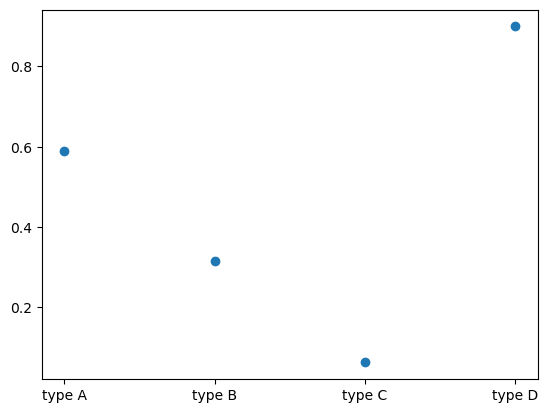

```python
models=['type A', 'type B', 'type C','type D']
best_R2 = [max_R2_A,max_R2_B,max_R2_C,max_R2_D]
plt.scatter([1,2,3,4],best_R2)
plt.xticks([1,2,3,4],models)
plt.show()
```

Thus, we choose type D KNN model where we take TV, Radio, and Newspaper budgets as our predictors and we choose the nearest neighbors to be equal to 3.